# Assignment8_Kelsey-Liu

### 3. Do you see seasonality in reviews?

- Is every product category getting consistent number of reviews throughout the year?
- Any product categories that are getting more reviews during certain times of the year? If yes, which product categories and what times of the year?

```python
review_df = review_df.withColumn('review_date', col('review_date').cast('date'))
```

```python
review_df_mon_yr = review_df.\
select([month('review_date').alias('review_month'), year('review_date').alias('review_year'), 'review_id', 'product_category'])
```

```python
pd_mon_yr = review_df_mon_yr.\
groupby('review_month', 'review_year').\
agg(count('*').alias('review_count')).\
toPandas()
```

```python
# pd_mon_yr.head()
# pd_mon_yr.review_year.unique()
```

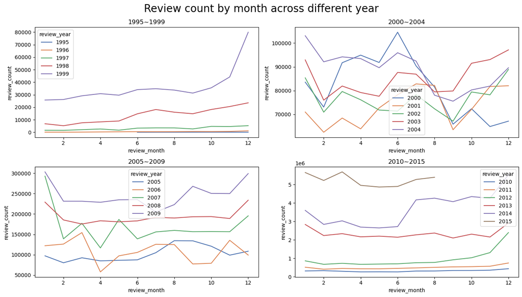

```python
# Since the value varies among different years, we separate them into 4 plots to closely observe the fluctuation.

import seaborn as sns
import matplotlib.pyplot as plt

fig, axes = plt.subplots(2, 2, figsize=(14, 8), sharey=False)
fig.suptitle("Review count by month across different year", size=20)

# 1995~1999
sns.lineplot(ax=axes[0, 0],
             data = pd_mon_yr.query('review_year<2000'),
             x = 'review_month',
             y = 'review_count',
             hue = 'review_year',
             palette = 'deep')
axes[0, 0].set_title("1995~1999")

# 2000~2004
sns.lineplot(ax=axes[0, 1],
             data = pd_mon_yr.query('review_year>=2000 & review_year<2005'),
             x = 'review_month',
             y = 'review_count',
             hue = 'review_year',
             palette = 'deep')
axes[0, 1].set_title("2000~2004")

# 2005~2009
sns.lineplot(ax=axes[1, 0],
             data = pd_mon_yr.query('review_year>=2005 & review_year<2010'),
             x = 'review_month',
             y = 'review_count',
             hue = 'review_year',
             palette = 'deep')
axes[1, 0].set_title(
    "2005~2009"
)

# 2010~2015
sns.lineplot(ax=axes[1, 1],
             data = pd_mon_yr.query('review_year>2009'),
             x = 'review_month',
             y = 'review_count',
             hue = 'review_year',
             palette = 'deep')
axes[1, 1].set_title(
    "2010~2015"
)

plt.tight_layout()
plt.show()
```

**The review count shows a clear seasonality in different years, possibly due to promotion or season needs.**

```python
pd_cat_mon = review_df_mon_yr.\
groupby('review_month', 'product_category').\
agg(count('*').alias('review_count')).\
toPandas()
```

```python
# pd_cat_mon.head()
```

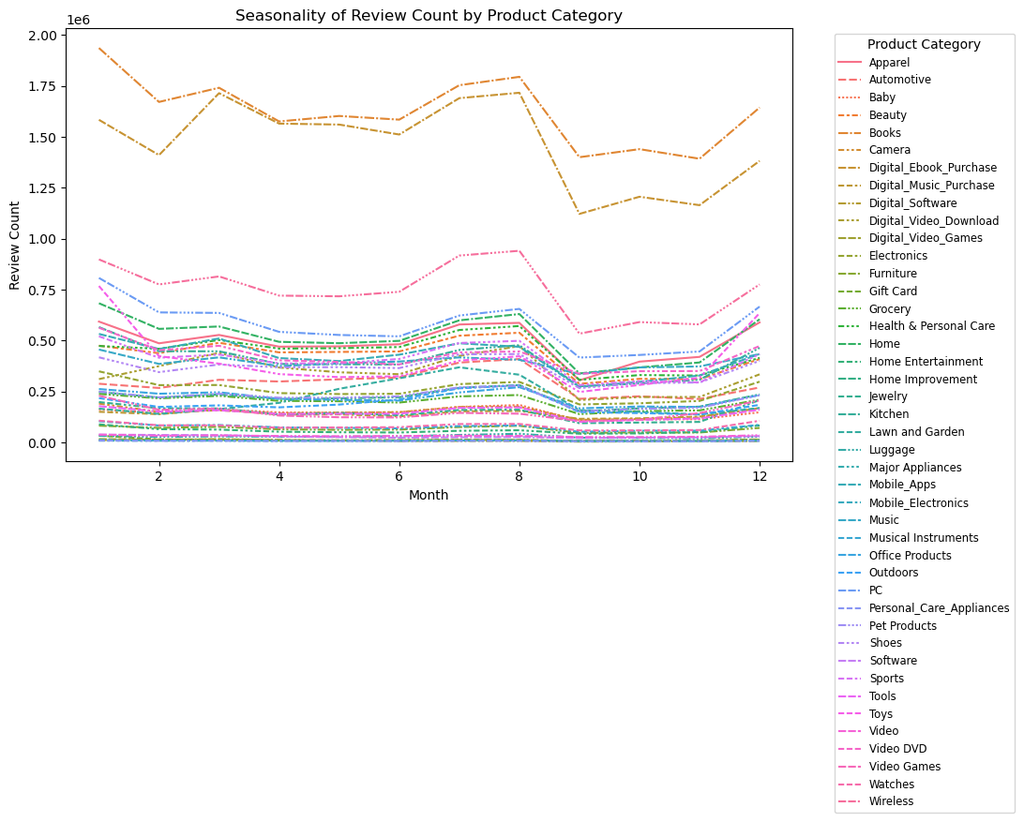

```python
# create a pivot table to aggregate review count by category and month
pivot_df = pd.pivot_table(pd_cat_mon, values='review_count', index='review_month', columns='product_category', aggfunc='sum')

# set the figure size and plot the pivot table using seaborn's lineplot function
plt.figure(figsize=(10, 6))
sns.lineplot(data=pivot_df)

# customize the plot
plt.xlabel('Month')
plt.ylabel('Review Count')
plt.title('Seasonality of Review Count by Product Category')
plt.legend(title='Product Category', bbox_to_anchor=(1.05, 1), loc='upper left', fontsize = 'small')
plt.show()
```

### 4. Which reviews are getting the most helpful votes / total votes?

- Any correlation between the length of review headline / review body (in number words) and the "helpfulness" of the review?

```python
from pyspark.sql.functions import split, size
from pyspark.sql.functions import corr

review_df_words = review_df.\
withColumn('headline_length', size(split(review_df.review_headline, ' '))).\
withColumn('body_length', size(split(review_df.review_body, ' '))).\
select('headline_length', 'body_length', 'helpful_votes')

review_df_words.cache()
```

| headline_length | body_length | helpful_votes |
| --- | --- | --- |
| 2 | 54 | 0 |
| 11 | 880 | 24 |
| 9 | 52 | 2 |
| 3 | 4 | 0 |
| 2 | 7 | 0 |
| 6 | 6 | 0 |
| 9 | 26 | 1 |
| 1 | 62 | 1 |
| 6 | 118 | 0 |
| 5 | 135 | 3 |
| 2 | 9 | 0 |
| 2 | 31 | 0 |
| 2 | 9 | 1 |
| 11 | 24 | 0 |
| 4 | 245 | 0 |
| 3 | 38 | 0 |
| 2 | 6 | 0 |
| 10 | 58 | 0 |
| 2 | 5 | 0 |
| 6 | 38 | 0 |

only showing top 20 rows

```python
review_df_words.corr('headline_length', 'helpful_votes')
```

```
0.030980526018484125
```

```python
review_df_words.corr('body_length', 'helpful_votes')
```

```
0.13785942999384293
```

```python
review_df_words.unpersist()
```

| headline_length | body_length | helpful_votes |
| --- | --- | --- |
| 2 | 54 | 0 |
| 11 | 880 | 24 |
| 9 | 52 | 2 |
| 3 | 4 | 0 |
| 2 | 7 | 0 |
| 6 | 6 | 0 |
| 9 | 26 | 1 |
| 1 | 62 | 1 |
| 6 | 118 | 0 |
| 5 | 135 | 3 |
| 2 | 9 | 0 |
| 2 | 31 | 0 |
| 2 | 9 | 1 |
| 11 | 24 | 0 |
| 4 | 245 | 0 |
| 3 | 38 | 0 |
| 2 | 6 | 0 |
| 10 | 58 | 0 |
| 2 | 5 | 0 |
| 6 | 38 | 0 |

only showing top 20 rows

**Correlation between:**  
**- Review headline length and helpful votes = 0.03.**  
**- Review body length and helpful votes = 0.14.**

**Although review body length and helpful votes has a slightly higher correlation than Review headline length and helpful votes does, both of them indicate a weak correlation, meaning people don't always find review (headline and body) with more words more helpful.**

- Do you see any correlation between how many reviews a certain customer (customer_id) published and the "helpfulness" of the reviews?

```python
## Here we define the helpfulness as the "average" of helpful_votes per customer.
review_df_cxid = review_df.\
select('customer_id', 'helpful_votes').\
groupby('customer_id').\
agg(avg('helpful_votes').alias('helpful_votes_mean'), count('*').alias('review_count'))
```

```python
review_df_cxid.corr('helpful_votes_mean', 'review_count')
```

```
-0.00018596383909280604
```

```python
## Here we define the helpfulness as the "sum" of helpful_votes per customer.
review_df_cxid = review_df.\
select('customer_id', 'helpful_votes').\
groupby('customer_id').\
agg(sum('helpful_votes').alias('helpful_votes_sum'), count('*').alias('review_count'))

review_df_cxid.cache()
```

| customer_id | helpful_votes_sum | review_count |
| --- | --- | --- |
| 13260322 | 1 | 25 |
| 43976638 | 0 | 8 |
| 4088819 | 4 | 8 |
| 52700418 | 1 | 9 |
| 32452910 | 0 | 1 |
| 46867020 | 0 | 2 |
| 40378966 | 24 | 8 |
| 23740346 | 33 | 30 |
| 15321785 | 31 | 24 |
| 22427775 | 3 | 17 |
| 12921767 | 13 | 37 |
| 1673761 | 0 | 2 |
| 24772859 | 7 | 3 |
| 30416085 | 2 | 13 |
| 12655464 | 4 | 9 |
| 21769451 | 18 | 8 |
| 1381655 | 9 | 9 |
| 23217434 | 0 | 1 |
| 50232755 | 5 | 23 |
| 11563579 | 38 | 83 |

only showing top 20 rows

```python
review_df_cxid.corr('helpful_votes_sum', 'review_count')
```

```
0.6549164783561697
```

**Similarly, there is a extremely low correlation (-0.0002) between how many reviews a certain customer published and the "helpfulness" of the reviews. On contrary, if we change the definition of the helpfulness from "the *average* of helpful_votes per customer" to "the *total* of helpful_votes per customer", it will show a rather high (0.65) correlation simply because the more reviews a customer left, the higher exposure he/she would get, however, that doesn't mean on average this customer's review is more helpful.**

```python
import datetime
import pytz

datetime.datetime.now(pytz.timezone('US/Central')).strftime("%a, %d %B %Y %H:%M:%S")
```

```
'Tue, 14 February 2023 19:49:59'
```